# R Notebook

Problem 1 generates random values from the dice random variable

```r
mydice <- function(R){
out <- rep(NA, R) # initialize output vector of length R
for (i in 1:R){
va<- runif(1,1,7)
if (va == 7){
while(va==7){
  va<- runif(1,1,7)
}
}
var <- floor(va)
out[i] <- var
}
return(out)
}
set.seed(1)
system.time(mysample <- mydice(100000))
```

```
##    user  system elapsed
##    0.32    0.05    0.39
```

```r
(Freq <- table(mysample)/100000)
```

```
## mysample
##       1       2       3       4       5       6
## 0.16913 0.16485 0.16610 0.16616 0.16735 0.16641
```

```r
(Freq <- table(mysample))
```

```
## mysample
##     1     2     3     4     5     6
## 16913 16485 16610 16616 16735 16641
```

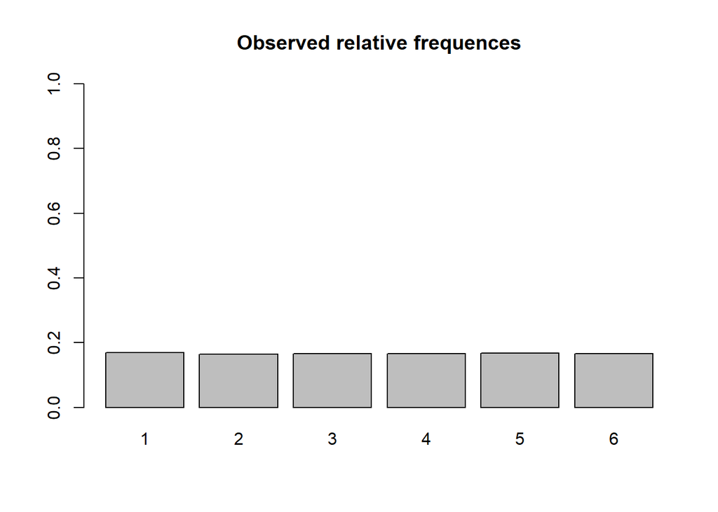

```r
barplot(Freq/100000, ylim= c(0,1),
main = "Observed relative frequences")
```

Problem 2 generates random values from a Exp(λ)-distribution using the probability integral transform method

Lemma 1.8 (Probability integral transform). If X is a continuous random variable with distribution function F(·) and inverse F^−1(·), then U := F(X) ∼ U[0, 1]. Therefore, if X := F^−1(U), then X ∼ F. The transformation U := F(X) is called the probability integral transform (PIT) of X

Since F(x) = 1 − exp(−λx), we have F^−1(u) = −(log(1−u))/λ. Note that 1 − U has the same distribution as U, if U ∼ U[0, 1], therefore −(log(1−u))/λ leads to a value from Exp(λ)

```r
#our PIT generated exponential function
myexp <- function(R,lambda){
out <- rep(NA, R) # initialize output vector of length R
for (i in 1:R){
va<- runif(1)
var<- -(log(1−va))/lambda
out[i] <- var
}
return(out)
}

#generates true exponential function
trueexp <- function(R,lambda){
out <- rep(NA, R) # initialize output vector of length R
for (i in 1:R){
var<- dexp(lambda)
out[i] <- var
}
return(out)
}

set.seed(1)
lambd<- 1

system.time(mysample <- myexp(100000,lambd))
```

```
##    user  system elapsed
##    0.29    0.00    0.32
```

```r
system.time(texp <- trueexp(100000,lambd))
```

```
##    user  system elapsed
##    0.18    0.00    0.18
```

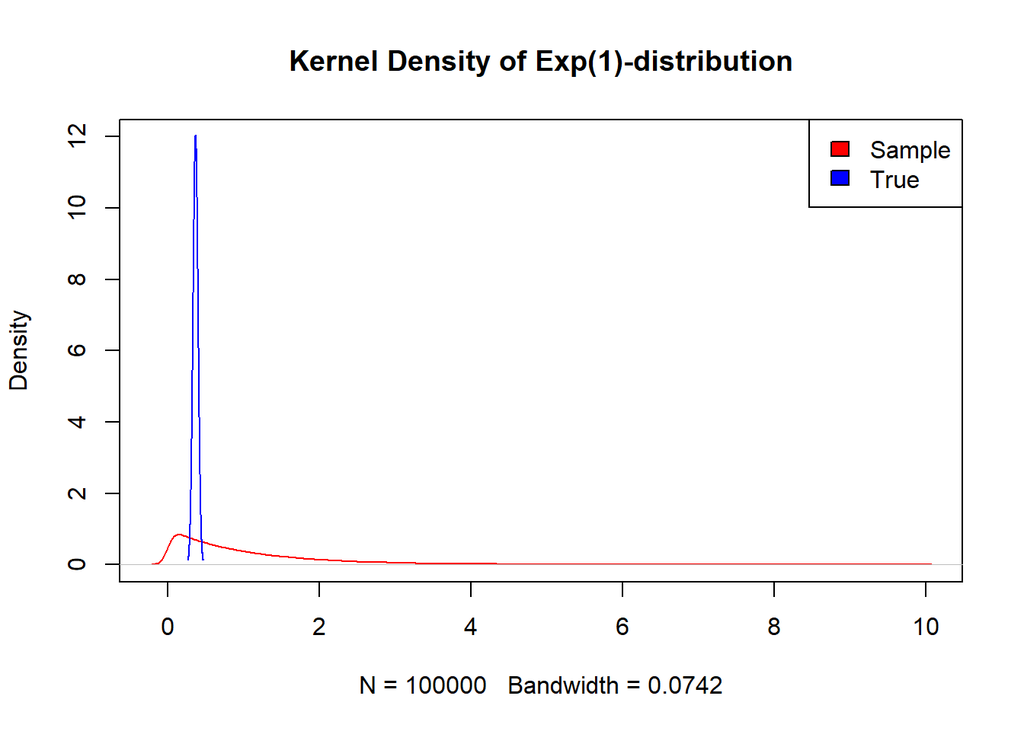

```r
# Kernel Density Plot
d <- density(mysample) # returns the density data from our PIT method
dt <- density(texp)#return true density function
plot(d,ylim=c(0,12),col="red",main="Kernel Density of Exp(1)-distribution")
lines(dt,col="blue")
legend("topright",c("Sample","True"),fill=c("red","blue"))
```

Problem 3 Let N(t) be a Poisson process with parameter λ. Using the properties (i)-(iii) given in the lecture (Definition 1.6 in the script) prove that N(t + s) − N(t) ∼ Poi(λs). Hint: The characteristic function for X ∼ Poi(λ) is φX(u) = exp(λ(exp(iu) − 1)).

N(t + s) ∼ Poi(λ(t+s)) and N(t)∼ Poi(λt). Because of the second property from definition 1.6, N(s) and N(t) − N(s) are independent for 0 < s < t, the poisson processes for N(t + s) − N(t) and N(t) are independent. And the distribution for N(t + s) − N(t) depends only on s. Subtracting the distributions Poi(λ(t+s))- Poi(λt) leaves us with N(t + s) − N(t) ∼ Poi(λs).

Lemma 1.7 (Generating Poisson integers based on realizations of exponential random variables). Generate independent exponential random realizations e1, e2, . . . from Exp(λ) i.i.d until e1 + · · · + ek+1 > 1 but e1 + · · · + ek ≤ 1 (1.2) then set x := k. Then x is a realization from Poi(λ).

```r
#I created a modifed version of the exp function for I coded this problem
mexp <- function(lambda){
va<- runif(1)
var<- -(log(1−va))/lambda
out <- var
return(out)
}
#our PIT generated exponential function
mypoi <- function(R,lambda){
out <- rep(NA, R) # initialize output vector of length R
for (i in 1:R){
  sum<- 0
  counter<- 0
  while(sum<=1){
    ek<-mexp(lambda)
    sum<- sum+ek
    counter<- counter+1
  }
out[i] <- counter-1
}
return(out)
}


set.seed(1)
lambd<- 10


system.time(mysample <- mypoi(100000,lambd))
```

```
##    user  system elapsed
##    5.44    0.07    5.86
```

```r
(Freq <- table(mysample))
```

```
## mysample
##     0     1     2     3     4     5     6     7     8     9    10    11    12
##     6    45   231   727  1810  3825  6170  9132 11290 12588 12530 11315  9465
##    13    14    15    16    17    18    19    20    21    22    23    24    25
##  7257  5332  3514  2097  1259   695   389   179    79    34    15    10     5
##    29
##     1
```

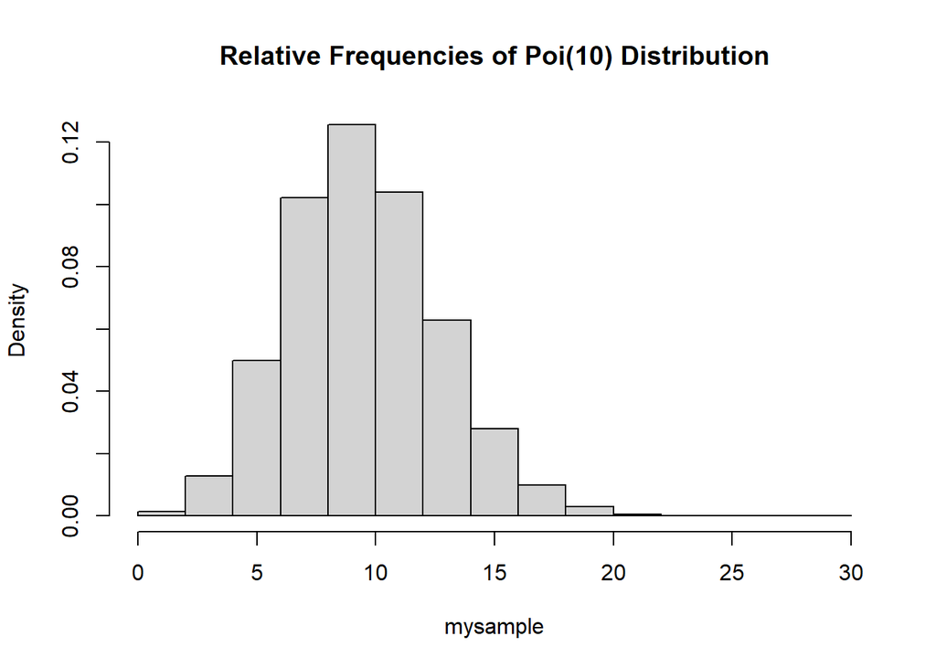

```r
hist(mysample,freq=FALSE,main="Relative Frequencies of Poi(10) Distribution")
```

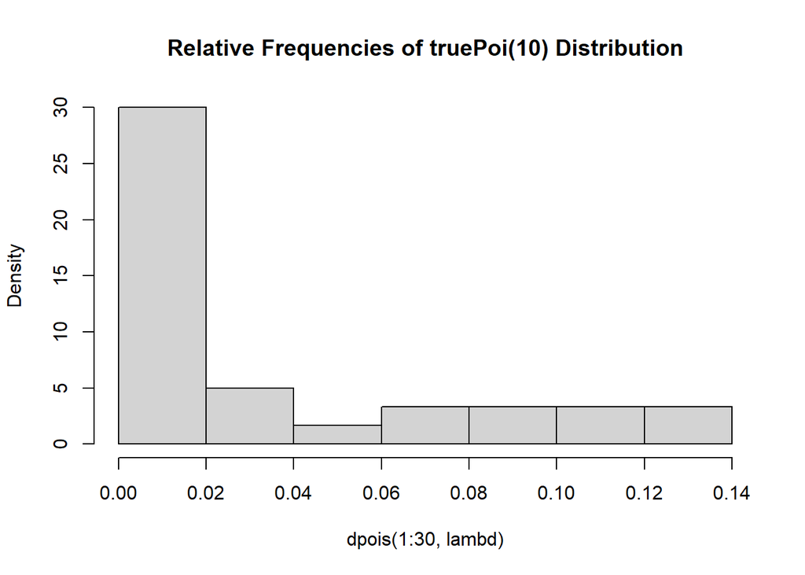

```r
hist(dpois(1:30,lambd),freq=FALSE,main="Relative Frequencies of truePoi(10) Distribution")
```